# LoD Classical Method Variables

## main_ep17: 主程式(vary by case)

## * setting:

## create empty lists

- `ep17lod_setting`
- `ep17lod_import`
- `ep17lod_tidy`
- `ep17lod_analysis`
- `ep17lod_report_fig`
- `ep17lod_report_tab`
- `ep17lod_report_crit`

## load pkg

`ep17lod_setting[["deps"]]`

## set path

`ep17lod_setting[["path"]]`

## * import: 匯入設定 & 資料

## setting

`ep17lod_import[["setting"]]`

## data

`ep17lod_import[["data"]]`

## * tidy: 整理資料

## combine: 單一表格

`ep17lod_tidy[["combine"]]`

## split: 依照reagent_lot拆分

`ep17lod_tidy[["split"]]`

- 拆分時建立易懂的名稱

## lib_ep17 (constant)

## * analysis: 資料分析

## Descriptive Statistics: 計算各樣品的Mean, SD, Ratio > LOB, Median

`ep17lod_analysis[["desc"]]`

## 以Shapiro-Wilk Test檢定SD是否為常態分佈

`ep17lod_analysis[["spw.p"]]`

## 計算cp

`ep17lod_analysis[["cp"]]`

## 取出reagent lot數量(作為後續if-loop判斷依據)

`ep17lod_analysis[["reagent_lot number"]]`

## 定義計算SDL公式

`get_sdl()`

- 從`ep17lod_tidy[["combine"]]`或是`ep17lod_tidy[["split"]]`中計算

## if-loop:

### reagent_lot≥4: 合併計算

`ep17lod_analysis[["lod"]]`

### reagent_lot≤3: 分批計算

`ep17lod_analysis[["lot lod"]]`

## if-loop: 若有`ep17lod_analysis[["lot lod"]]`, 則合併並計算final LoD

`ep17lod_analysis[["lod"]]`

## 計算non-parametric option

`ep17lod_analysis[["non-parametric lod"]]`

## * report_fig: 圖形報表

`ep17lod_report_fig[["raw"]]`

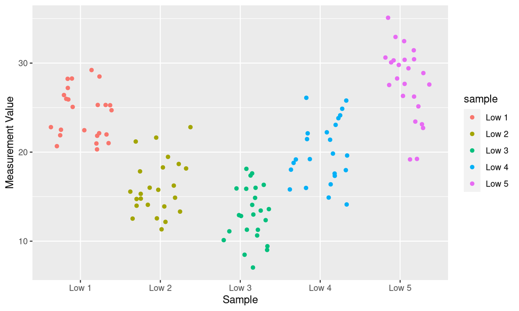

## 濃度 VS SD (color = reagent lot)

`ep17lod_report_fig[["sd"]]`

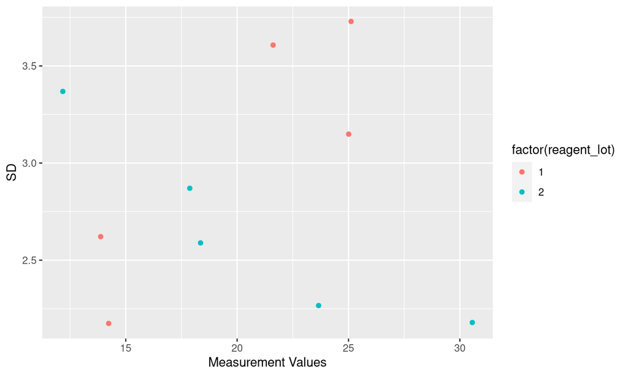

## qqplot of SD

`ep17lod_report_fig[["qq"]]`

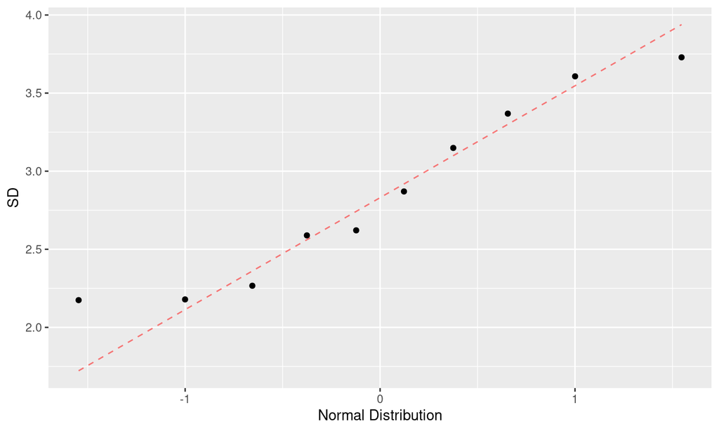

## * report_tab: 表格報表

## 各樣品 x 各濃度的parametric descriptive statistics

`ep17lod_report_tab[["raw parametric"]]`

| Sample | Reagent Lot | N | Mean | SD |
| --- | --- | --- | --- | --- |
| Low 1 | 1 | 12 | 25.008 | 3.149 |
| Low 2 | 1 | 12 | 14.233 | 2.174 |
| Low 3 | 1 | 12 | 13.875 | 2.621 |
| Low 4 | 1 | 12 | 21.617 | 3.607 |
| Low 5 | 1 | 12 | 25.117 | 3.729 |
| Low 1 | 2 | 12 | 23.658 | 2.267 |
| Low 2 | 2 | 12 | 17.875 | 2.870 |
| Low 3 | 2 | 12 | 12.175 | 3.369 |
| Low 4 | 2 | 12 | 18.358 | 2.589 |
| Low 5 | 2 | 12 | 30.558 | 2.179 |

unit of mean and SD: pg/ml Shapiro-Wilk Test of SD: p = 0.318

## 各樣品 x 各濃度的non-parametric descriptive statistics

`ep17lod_report_tab[["raw non-parametric"]]`

| Sample | Reagent Lot | N | Ratio > LoB | Median |
| --- | --- | --- | --- | --- |
| Low 1 | 1 | 12 | 1.000 | 25.30 |
| Low 1 | 2 | 12 | 1.000 | 23.80 |
| Low 2 | 1 | 12 | 1.000 | 13.95 |
| Low 2 | 2 | 12 | 1.000 | 17.15 |
| Low 3 | 1 | 12 | 0.917 | 13.85 |
| Low 3 | 2 | 12 | 0.750 | 11.85 |
| Low 4 | 1 | 12 | 1.000 | 22.15 |
| Low 4 | 2 | 12 | 1.000 | 18.40 |
| Low 5 | 1 | 12 | 1.000 | 25.65 |
| Low 5 | 2 | 12 | 1.000 | 30.40 |

unit of median: pg/ml Shapiro-Wilk Test of SD: p = 0.318